# Summarising Your Data

Andrew Stewart, Email: drandrewjstewart@gmail.com, Twitter: @ajstewart_lang

First well work out the average highway fuel economy (measured in the `hwy` column) for each car manufacturer. Then we’ll work out how many of each manufacturer there are using the `n()` function.

Remember to set up a .Rproj file for this workshop before continuing. In your script, you’ll first need to load the tidyverse.

```r
library(tidyverse)
```

# Using `group_by()` and `summarise()`

We are going to use the `group_by()` function to group the dataset, and then the `summarise()` function to calculate the mean of hte `hwy` variable. The `summarise()` function can take a lot of different functions to give us summary statistics. To read more about the different options, type `?summarise` in the Console window. Commonly used ones are `mean()`, `median()`, `sd()`.

```r
mpg %>%
  group_by(manufacturer) %>%
  summarise(mean_hwy = mean(hwy), number = n())
```

```
## # A tibble: 15 x 3
##    manufacturer mean_hwy number
##    <chr>           <dbl>  <int>
##  1 audi             26.4     18
##  2 chevrolet        21.9     19
##  3 dodge            17.9     37
##  4 ford             19.4     25
##  5 honda            32.6      9
##  6 hyundai          26.9     14
##  7 jeep             17.6      8
##  8 land rover       16.5      4
##  9 lincoln          17        3
## 10 mercury          18        4
## 11 nissan           24.6     13
## 12 pontiac          26.4      5
## 13 subaru           25.6     14
## 14 toyota           24.9     34
## 15 volkswagen       29.2     27
```

Note that this output is currently ordered alphabetically by the first column `manufacturer`. What if we wanted to order this out by mean highway fuel economy highest (best) to lowest (worst)? We can use the arrange function.

## Re-ordering the output with `arrange()`

```r
mpg %>%
  group_by(manufacturer) %>%
  summarise(mean_hwy = mean(hwy), number = n()) %>%
  arrange(mean_hwy)
```

```
## # A tibble: 15 x 3
##    manufacturer mean_hwy number
##    <chr>           <dbl>  <int>
##  1 land rover       16.5      4
##  2 lincoln          17        3
##  3 jeep             17.6      8
##  4 dodge            17.9     37
##  5 mercury          18        4
##  6 ford             19.4     25
##  7 chevrolet        21.9     19
##  8 nissan           24.6     13
##  9 toyota           24.9     34
## 10 subaru           25.6     14
## 11 pontiac          26.4      5
## 12 audi             26.4     18
## 13 hyundai          26.9     14
## 14 volkswagen       29.2     27
## 15 honda            32.6      9
```

Hmm, so that isn’t what we want - this is going from lowest to highest which is the default in R. We can change that by putting a `-` sign in from of the parameter we can to order by.

```r
mpg %>%
  group_by(manufacturer) %>%
  summarise(mean_hwy = mean(hwy), number = n()) %>%
  arrange(- mean_hwy)
```

```
## # A tibble: 15 x 3
##    manufacturer mean_hwy number
##    <chr>           <dbl>  <int>
##  1 honda            32.6      9
##  2 volkswagen       29.2     27
##  3 hyundai          26.9     14
##  4 audi             26.4     18
##  5 pontiac          26.4      5
##  6 subaru           25.6     14
##  7 toyota           24.9     34
##  8 nissan           24.6     13
##  9 chevrolet        21.9     19
## 10 ford             19.4     25
## 11 mercury          18        4
## 12 dodge            17.9     37
## 13 jeep             17.6      8
## 14 lincoln          17        3
## 15 land rover       16.5      4
```

This is looking better.

## The `summarise_at()` variant

As well as using `summarise()`, you can use related functions such as `summarise_at()`. This is a scoped version of the `summarise()` function that can be applied across multiple columns. Note, when using `summarise_at()` you need to put the columns you want to summarise over in quotes. You also need to provide the summary function - in this case `mean`. Finally, in case our dataset contains any missing values (indicated by `NA`), we set the parameter `na.rm = TRUE`. This will ensure that missing data points are removed before the operation is applied. If we had missing data, but didn’t tell R what we wanted to do with it, it would have thrown an error.

```r
mpg %>%
  group_by(manufacturer) %>%
  summarise_at(c("displ", "cty", "hwy"), mean, na.rm = TRUE)
```

```
## # A tibble: 15 x 4
##    manufacturer displ   cty   hwy
##    <chr>        <dbl> <dbl> <dbl>
##  1 audi          2.54  17.6  26.4
##  2 chevrolet     5.06  15    21.9
##  3 dodge         4.38  13.1  17.9
##  4 ford          4.54  14    19.4
##  5 honda         1.71  24.4  32.6
##  6 hyundai       2.43  18.6  26.9
##  7 jeep          4.58  13.5  17.6
##  8 land rover    4.3   11.5  16.5
##  9 lincoln       5.4   11.3  17
## 10 mercury       4.4   13.2  18
## 11 nissan        3.27  18.1  24.6
## 12 pontiac       3.96  17    26.4
## 13 subaru        2.46  19.3  25.6
## 14 toyota        2.95  18.5  24.9
## 15 volkswagen    2.26  20.9  29.2
```

## The `summarise_if()` variant

Imagine we had a really big dataset and wanted to summarise all columns that were of a certain type. We can use the `summarise_if()` function to work out the mean for each of our car manufactures as follows:

```r
mpg %>%
  group_by(manufacturer) %>%
  summarise_if(is.numeric, mean, na.rm = TRUE)
```

```
## # A tibble: 15 x 6
##    manufacturer displ  year   cyl   cty   hwy
##    <chr>        <dbl> <dbl> <dbl> <dbl> <dbl>
##  1 audi          2.54 2004.  5.22  17.6  26.4
##  2 chevrolet     5.06 2005.  7.26  15    21.9
##  3 dodge         4.38 2004.  7.08  13.1  17.9
##  4 ford          4.54 2003.  7.2   14    19.4
##  5 honda         1.71 2003   4     24.4  32.6
##  6 hyundai       2.43 2004.  4.86  18.6  26.9
##  7 jeep          4.58 2006.  7.25  13.5  17.6
##  8 land rover    4.3  2004.  8     11.5  16.5
##  9 lincoln       5.4  2002   8     11.3  17
## 10 mercury       4.4  2004.  7     13.2  18
## 11 nissan        3.27 2004.  5.54  18.1  24.6
## 12 pontiac       3.96 2003.  6.4   17    26.4
## 13 subaru        2.46 2004.  4     19.3  25.6
## 14 toyota        2.95 2003.  5.12  18.5  24.9
## 15 volkswagen    2.26 2003.  4.59  20.9  29.2
```

The first parameter in `summarise_if()` is the logical test applied to each column - in this case, if a column is numeric (i.e., a number) - then the test evaluates to TRUE and the second function, `mean`, is applied. Again, we tell R to ignore missing (`NA`) data values with the `na.rm = TRUE` parameter.

R functions differ in terms of what arguments they take. I often forget them - if you start typing a function name, you’ll get a little bubble above where you’re typing to remind you what parameters are needed. And if you can’t remember the details, you can just type `help(function_name)` or `?function_name` in the console for any function that you need help with. A lot of data analysis with R (or Python or wny other language really) involves a fair bit of Googling. This is normal. There are some things I can never remember and am always having to look up!

# Adding columns using `mutate()`

We can add a new column that I’m calling `mean_hwy` using the `mutate()` function like this.

```r
mpg %>%
  group_by(manufacturer) %>%
  mutate(mean_hwy = mean(hwy))
```

```
## # A tibble: 234 x 12
## # Groups:   manufacturer [15]
##    manufacturer model displ  year   cyl trans drv     cty   hwy fl    class
##    <chr>        <chr> <dbl> <int> <int> <chr> <chr> <int> <int> <chr> <chr>
##  1 audi         a4      1.8  1999     4 auto… f        18    29 p     comp…
##  2 audi         a4      1.8  1999     4 manu… f        21    29 p     comp…
##  3 audi         a4      2    2008     4 manu… f        20    31 p     comp…
##  4 audi         a4      2    2008     4 auto… f        21    30 p     comp…
##  5 audi         a4      2.8  1999     6 auto… f        16    26 p     comp…
##  6 audi         a4      2.8  1999     6 manu… f        18    26 p     comp…
##  7 audi         a4      3.1  2008     6 auto… f        18    27 p     comp…
##  8 audi         a4 q…   1.8  1999     4 manu… 4        18    26 p     comp…
##  9 audi         a4 q…   1.8  1999     4 auto… 4        16    25 p     comp…
## 10 audi         a4 q…   2    2008     4 manu… 4        20    28 p     comp…
## # … with 224 more rows, and 1 more variable: mean_hwy <dbl>
```

```r
mpg %>%
  group_by(manufacturer) %>%
  mutate(mean_hwy = mean(hwy)) %>%
  select(- class, trans)
```

```
## # A tibble: 234 x 11
## # Groups:   manufacturer [15]
##    manufacturer model displ  year   cyl trans drv     cty   hwy fl
##    <chr>        <chr> <dbl> <int> <int> <chr> <chr> <int> <int> <chr>
##  1 audi         a4      1.8  1999     4 auto… f        18    29 p
##  2 audi         a4      1.8  1999     4 manu… f        21    29 p
##  3 audi         a4      2    2008     4 manu… f        20    31 p
##  4 audi         a4      2    2008     4 auto… f        21    30 p
##  5 audi         a4      2.8  1999     6 auto… f        16    26 p
##  6 audi         a4      2.8  1999     6 manu… f        18    26 p
##  7 audi         a4      3.1  2008     6 auto… f        18    27 p
##  8 audi         a4 q…   1.8  1999     4 manu… 4        18    26 p
##  9 audi         a4 q…   1.8  1999     4 auto… 4        16    25 p
## 10 audi         a4 q…   2    2008     4 manu… 4        20    28 p
## # … with 224 more rows, and 1 more variable: mean_hwy <dbl>
```

Note that this doesn’t change the `mpg` dataset permanently - the changes won’t be saved unless we map the output of this code onto a new variable. Below I am doing this by using the assignment operator `<-` to map it onto a new variable I’m calling `mpg_with_mean`. Note that we remove the grouping at the end as we don’t want our grouping rule to remain in our new data frame.

```r
mpg_with_mean <- mpg %>%
  group_by(manufacturer) %>%
  mutate(mean_hwy = mean(hwy)) %>%
  ungroup() %>%
  select(- class)
```

We can then inspect this new variable using `head()` and `str()`.

```r
head(mpg_with_mean)
```

```
## # A tibble: 6 x 11
##   manufacturer model displ  year   cyl trans drv     cty   hwy fl
##   <chr>        <chr> <dbl> <int> <int> <chr> <chr> <int> <int> <chr>
## 1 audi         a4      1.8  1999     4 auto… f        18    29 p
## 2 audi         a4      1.8  1999     4 manu… f        21    29 p
## 3 audi         a4      2    2008     4 manu… f        20    31 p
## 4 audi         a4      2    2008     4 auto… f        21    30 p
## 5 audi         a4      2.8  1999     6 auto… f        16    26 p
## 6 audi         a4      2.8  1999     6 manu… f        18    26 p
## # … with 1 more variable: mean_hwy <dbl>
```

```r
str(mpg_with_mean)
```

```
## Classes 'tbl_df', 'tbl' and 'data.frame':    234 obs. of  11 variables:
##  $ manufacturer: chr  "audi" "audi" "audi" "audi" ...
##  $ model       : chr  "a4" "a4" "a4" "a4" ...
##  $ displ       : num  1.8 1.8 2 2 2.8 2.8 3.1 1.8 1.8 2 ...
##  $ year        : int  1999 1999 2008 2008 1999 1999 2008 1999 1999 2008 ...
##  $ cyl         : int  4 4 4 4 6 6 6 4 4 4 ...
##  $ trans       : chr  "auto(l5)" "manual(m5)" "manual(m6)" "auto(av)" ...
##  $ drv         : chr  "f" "f" "f" "f" ...
##  $ cty         : int  18 21 20 21 16 18 18 18 16 20 ...
##  $ hwy         : int  29 29 31 30 26 26 27 26 25 28 ...
##  $ fl          : chr  "p" "p" "p" "p" ...
##  $ mean_hwy    : num  26.4 26.4 26.4 26.4 26.4 ...
```

Wouldn’t it be great if we could also visualize the entire dataset? We can use the function `vis_dat()` from the packages `visdat::` to do just that.

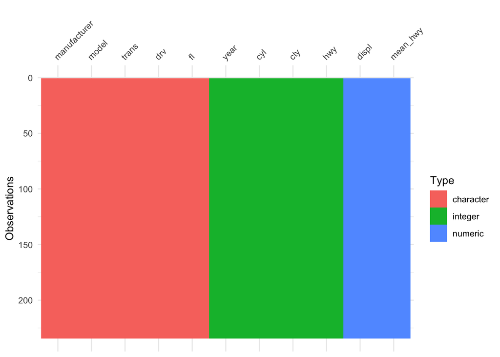

```r
library(visdat)
vis_dat(mpg_with_mean)
```

Note, our variables (i.e., the columns in our dataset) are vectors (sequences of data elements) that include type `character`, `integer`, or `numeric`. Vectors of type `integer` are whole numbers. You can think of integer vectors as being a subset of numeric vectors.

# Your challenge

The `Tidyverse` has a number of other built-in data sets. Another one is the `starwars` data set. You can have a look at it by typing `starwars` or by typing `view(starwars)`. This second option will open the data set in a new window. Have a go playing around with it. Work out the mean height of humans in the Star Wars universe. There might be some missing data (indicated by `NA`). You can use the `na.rm = TRUE` parameter in your `summarise()` function to ignore these values when generating your summary statistics.

Another way to filter out `NA` values is to use the `filter()` function in your pipeline. The function `is.na()` returns a logical value of TRUE of FALSE. The operator `!` means NOT, so the expression `!is.na(height)` will return TRUE when the height value is present, and FALSE if absent. By combining this with `filter()` we have the line `filter(!is.na(height))` which will filter only the cases where we have height data (i.e., `!is.na(height)` is TRUE). So your code might look like this:

```r
starwars %>%
  filter(!is.na(height)) %>%
  filter(species == "Human") %>%
  summarise(mean_height = mean(height))
```

Replace the word `mean` in the `summarise()` line with `median`. What other things can you replace it with? Hint: type `?summarise` in the console. What other summary information can you extract from this dataset?